# Machine Learning Assignment

Ariel Gershman

5/3/2022

## Overview

Using devices such as Jawbone Up, Nike FuelBand, and Fitbit it is now possible to collect a large amount of data about personal activity relatively inexpensively. These type of devices are part of the quantified self movement – a group of enthusiasts who take measurements about themselves regularly to improve their health, to find patterns in their behavior, or because they are tech geeks. One thing that people regularly do is quantify how much of a particular activity they do, but they rarely quantify how well they do it. In this project, your goal will be to use data from accelerometers on the belt, forearm, arm, and dumbell of 6 participants. They were asked to perform barbell lifts correctly and incorrectly in 5 different ways. More information is available from the website here: http://groupware.les.inf.puc-rio.br/har (see the section on the Weight Lifting Exercise Dataset).

Data The training data for this project are available here:

https://d396qusza40orc.cloudfront.net/predmachlearn/pml-training.csv

The test data are available here:

https://d396qusza40orc.cloudfront.net/predmachlearn/pml-testing.csv

The data for this project come from this source: http://groupware.les.inf.puc-rio.br/har.

First we will load in the data and using the carat package split the data into the training set and test set (70% for training, 30% for test).

```r
library(caret)
```

```r
setwd("~/CourseHera/Machine_Learning/")
trainURL <- "http://d396qusza40orc.cloudfront.net/predmachlearn/pml-training.csv"
testURL <- "http://d396qusza40orc.cloudfront.net/predmachlearn/pml-testing.csv"

training <- read.csv(url(trainURL))
testing <- read.csv(url(testURL))

label <- createDataPartition(training$classe, p = 0.7, list = FALSE)
train <- training[label, ]
test <- training[-label, ]
```

```r
nonZero <- nearZeroVar(train)
train <- train[ ,-nonZero]
test <- test[ ,-nonZero]

lab <- apply(train, 2, function(x) mean(is.na(x))) > 0.90
train <- train[, -which(lab, label == FALSE)]
test <- test[, -which(lab, label == FALSE)]

train <- train[ , -(1:5)]
test <- test[ , -(1:5)]
```

## Data Exploration

Now that the dataset is cleaned, we look at how all these variables correlate with one another through a correlation plot.

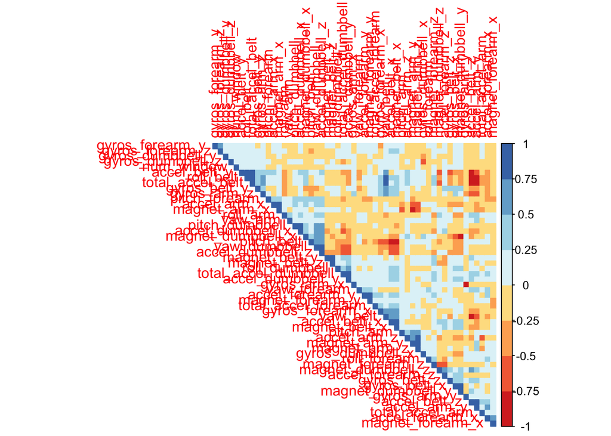

Figure 1. A correlation plot between all the variables. The more blue the more highly correlated variables are.

## Prediction Model Selection

# 1. Random Forest

```r
# model fit
set.seed(12312)
controlRF <- trainControl(method="cv", number=3, verboseIter=FALSE)
modFitRandForest <- train(classe ~ ., data=train, method="rf",
                          trControl=controlRF)
modFitRandForest$finalModel
```

```
##
## Call:
##  randomForest(x = x, y = y, mtry = min(param$mtry, ncol(x)))
##                Type of random forest: classification
##                      Number of trees: 500
## No. of variables tried at each split: 27
##
##         OOB estimate of  error rate: 0.17%
## Confusion matrix:
##      A    B    C    D    E  class.error
## A 3906    0    0    0    0 0.0000000000
## B    7 2648    3    0    0 0.0037622272
## C    0    2 2394    0    0 0.0008347245
## D    0    0    6 2246    0 0.0026642984
## E    0    0    0    5 2520 0.0019801980
```

```r
# prediction on Test dataset
predictRandForest <- predict(modFitRandForest,test)
confMatRandForest <- confusionMatrix(predictRandForest, as.factor(test$classe))
confMatRandForest
```

```
## Confusion Matrix and Statistics
##
##           Reference
## Prediction    A    B    C    D    E
##          A 1672    2    0    0    0
##          B    1 1137    6    0    2
##          C    0    0 1020    4    0
##          D    0    0    0  958    0
##          E    1    0    0    2 1080
##
## Overall Statistics
##
##                Accuracy : 0.9969
##                  95% CI : (0.9952, 0.9982)
##     No Information Rate : 0.2845
##     P-Value [Acc > NIR] : < 2.2e-16
##
##                   Kappa : 0.9961
##
##  Mcnemar's Test P-Value : NA
##
## Statistics by Class:
##
##                      Class: A Class: B Class: C Class: D Class: E
## Sensitivity            0.9988   0.9982   0.9942   0.9938   0.9982
## Specificity            0.9995   0.9981   0.9992   1.0000   0.9994
## Pos Pred Value         0.9988   0.9921   0.9961   1.0000   0.9972
## Neg Pred Value         0.9995   0.9996   0.9988   0.9988   0.9996
## Prevalence             0.2845   0.1935   0.1743   0.1638   0.1839
## Detection Rate         0.2841   0.1932   0.1733   0.1628   0.1835
## Detection Prevalence   0.2845   0.1947   0.1740   0.1628   0.1840
## Balanced Accuracy      0.9992   0.9982   0.9967   0.9969   0.9988
```

# 2. Decision Tree

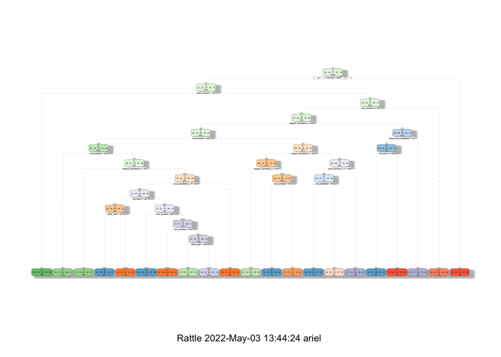

```r
library(rpart)
library(rpart.plot)
library(rattle)
set.seed(342142)
DTmod <- rpart(classe ~ ., data = train, method = "class")
fancyRpartPlot(DTmod)
```

```r
DTpred <- predict(DTmod, test, type = "class")
DTconfmat <- confusionMatrix(DTpred, as.factor(test$classe))
DTconfmat
```

```
## Confusion Matrix and Statistics
##
##           Reference
## Prediction    A    B    C    D    E
##          A 1472  259   49   84   49
##          B   43  614   30   18   20
##          C   15   70  835  136   73
##          D  102  135   51  625  119
##          E   42   61   61  101  821
##
## Overall Statistics
##
##                Accuracy : 0.7421
##                  95% CI : (0.7307, 0.7532)
##     No Information Rate : 0.2845
##     P-Value [Acc > NIR] : < 2.2e-16
##
##                   Kappa : 0.6725
##
##  Mcnemar's Test P-Value : < 2.2e-16
##
## Statistics by Class:
##
##                      Class: A Class: B Class: C Class: D Class: E
## Sensitivity            0.8793   0.5391   0.8138   0.6483   0.7588
## Specificity            0.8953   0.9766   0.9395   0.9173   0.9448
## Pos Pred Value         0.7695   0.8469   0.7396   0.6056   0.7560
## Neg Pred Value         0.9491   0.8983   0.9598   0.9301   0.9456
## Prevalence             0.2845   0.1935   0.1743   0.1638   0.1839
## Detection Rate         0.2501   0.1043   0.1419   0.1062   0.1395
## Detection Prevalence   0.3251   0.1232   0.1918   0.1754   0.1845
## Balanced Accuracy      0.8873   0.7578   0.8767   0.7828   0.8518
```

# 3. Generatlized Boosted Model

```r
set.seed(51354)
cont <- trainControl(method = "repeatedcv", number = 5, repeats = 1, verboseIter = FALSE)
GBM <- train(classe ~ ., data = train, trControl = cont, method = "gbm", verbose = FALSE)
GBM$finalModel
```

```
## A gradient boosted model with multinomial loss function.
## 150 iterations were performed.
## There were 53 predictors of which 53 had non-zero influence.
```

## Prediction

```r
RF <- predict(modFitRandForest, testing)
RF
```

```
##  [1] B A B A A E D B A A B C B A E E A B B B
## Levels: A B C D E
```